# Regression Analysis - STAT 482 - Exam 2: Due Dec 14, 2021

Alex Towell (atowell@siue.edu)

# Problem 1

> A beer distributor is interested in the amount of time to service its retail outlets. Two factors are thought to influence the delivery time ($y$) in minutes: the number of cases delivered ($x_1$) and the distance traveled ($x_2$) in miles. A random sample of delivery time data has been collected. The data is available on Blackboard as a csv file.

## P1: (a)

> Provide an interpretation of a regression coefficient in a multiple regression model.

## P1: (b)

> Compute $b_1,b_2$, the estimated the regression coefficients for the delivery time data.

```r
data1 = read.csv('exam2-1.csv')
head(data1)
```

```
##   cases distance time
## 1    10       30   24
## 2    15       25   27
## 3    10       40   28
## 4    20       18   33
## 5    25       22   35
## 6    18       31   32
```

```r
data1.m12 = lm(time ~ cases + distance, data=data1)
data1.m12
```

```
##
## Call:
## lm(formula = time ~ cases + distance, data = data1)
##
## Coefficients:
## (Intercept)        cases     distance
##      5.8933       0.9206       0.3286
```

## P1: (c)

> Compute $t$ statistics for testing the effect of each input variable. Explain what type of effect is being tested here.

```r
coef(summary(data1.m12))
```

```
##              Estimate Std. Error   t value     Pr(>|t|)
## (Intercept) 5.8932559 2.62973524  2.241007 4.471588e-02
## cases       0.9206362 0.06870747 13.399360 1.402168e-08
## distance    0.3286414 0.06589144  4.987620 3.157935e-04
```

## P1: (d)

> Compute $\sos{R}(X_1)$ and $\sos{R}(X_2|X_1)$. Explain what each sum of squares represents.

```r
anova(data1.m12)
```

```
## Analysis of Variance Table
##
## Response: time
##           Df  Sum Sq Mean Sq F value    Pr(>F)
## cases      1 308.008 308.008 154.901 3.217e-08 ***
## distance   1  49.464  49.464  24.876 0.0003158 ***
## Residuals 12  23.861   1.988
## ---
## Signif. codes:  0 '***' 0.001 '**' 0.01 '*' 0.05 '.' 0.1 ' ' 1
```

## P1: (e)

> Test for a marginal effect of $x_2$ against a model which includes no other input variables. (Compute the test statistic and $p$-value.) Provide an interpretation of the result, stated in the context of the problem.

```r
data1.m0 = lm(time ~ 1, data=data1)
data1.m2 = lm(time ~ distance, data=data1)
anova(data1.m2)
```

```
## Analysis of Variance Table
##
## Response: time
##           Df Sum Sq Mean Sq F value Pr(>F)
## distance   1   0.47  0.4672  0.0159 0.9014
## Residuals 13 380.87 29.2974
```

```r
anova(data1.m0,data1.m2)  # equivalent to anova(data1.m2)
```

```
## Analysis of Variance Table
##
## Model 1: time ~ 1
## Model 2: time ~ distance
##   Res.Df    RSS Df Sum of Sq      F Pr(>F)
## 1     14 381.33
## 2     13 380.87  1   0.46715 0.0159 0.9014
```

## P1: (f)

> Test for a partial effect of $x_2$ against a model which includes $x_1$. (Compute the test statistic and $p$-value.) Provide an interpretation of the result, stated in the context of the problem.

```r
data1.m1 = lm(time ~ cases, data=data1)
anova(data1.m1,data1.m12)
```

```
## Analysis of Variance Table
##
## Model 1: time ~ cases
## Model 2: time ~ cases + distance
##   Res.Df    RSS Df Sum of Sq      F    Pr(>F)
## 1     13 73.325
## 2     12 23.861  1    49.464 24.876 0.0003158 ***
## ---
## Signif. codes:  0 '***' 0.001 '**' 0.01 '*' 0.05 '.' 0.1 ' ' 1
```

## P1: (g)

> Compute the correlation matrix. What feature of multidimensional modeling is illustrated in this problem?

```r
cor(data1)
```

```
##               cases    distance        time
## cases     1.0000000 -0.40529762  0.89872861
## distance -0.4052976  1.00000000 -0.03500075
## time      0.8987286 -0.03500075  1.00000000
```

# Problem 2

> A bakery is interested in the best formulation for a new product. A small-scale experiment is conducted to investigate the relationship between the product satisfaction ($y$), and the moisture content (input 1) and sweetness (input 2) of the product. The input variables have been coded $(x_1,x_2)$ for ease of calculation. The data is available on Blackboard as a csv file.

## P2: (c)

> Fit an interaction model using the coded variables. Compute the regression coefficient estimates and their standard errors.

```r
data2 = read.csv('exam2-2.csv')
data2
```

```
##    moisture x1 sweetness x2 satisfaction
## 1         4 -3         2 -1           65
## 2         4 -3         4  1           75
## 3         4 -3         2 -1           61
## 4         4 -3         4  1           76
## 5         6 -1         2 -1           75
## 6         6 -1         4  1           86
## 7         6 -1         2 -1           72
## 8         6 -1         4  1           85
## 9         8  1         2 -1           87
## 10        8  1         4  1           87
## 11        8  1         2 -1           80
## 12        8  1         4  1           88
## 13       10  3         2 -1           91
## 14       10  3         4  1           96
## 15       10  3         2 -1           89
## 16       10  3         4  1           99
```

```r
data2.xmod = lm(satisfaction ~ x1*x2, data=data2)
summary(data2.xmod)
```

```
##
## Call:
## lm(formula = satisfaction ~ x1 * x2, data = data2)
##
## Residuals:
##    Min     1Q Median     3Q    Max
## -2.900 -1.938 -0.500  1.938  4.950
##
## Coefficients:
##             Estimate Std. Error t value Pr(>|t|)
## (Intercept)  82.0000     0.6435 127.433  < 2e-16 ***
## x1            3.9750     0.2878  13.813 9.94e-09 ***
## x2            4.5000     0.6435   6.993 1.45e-05 ***
## x1:x2        -0.5750     0.2878  -1.998   0.0689 .
## ---
## Signif. codes:  0 '***' 0.001 '**' 0.01 '*' 0.05 '.' 0.1 ' ' 1
##
## Residual standard error: 2.574 on 12 degrees of freedom
## Multiple R-squared:  0.9531, Adjusted R-squared:  0.9413
## F-statistic: 81.23 on 3 and 12 DF,  p-value: 3.069e-08
```

## P2: (d)

> Write the estimated regression as a function of $x_1$ for $x_2 = 1,0,-1$.

```r
b0 = coef(data2.xmod)[1]
b1 = coef(data2.xmod)[2]
b2 = coef(data2.xmod)[3]
b12 = coef(data2.xmod)[4]
reg.est.x1 = matrix(c(b0+b2,b1+b12,  # x2=+1
                      b0,b1,         # x2=0
                      b0-b2,b1-b12), # x2=-1
                    nrow=3,byrow=T)

dimnames(reg.est.x1) = list(c("x2=+1","x2=0","x2=-1"),c("intercept","slope"))
reg.est.x1
```

```
##       intercept slope
## x2=+1      86.5 3.400
## x2=0       82.0 3.975
## x2=-1      77.5 4.550
```

## P2: (e)

> Create interaction plots for both the interaction model and the additive effects model.

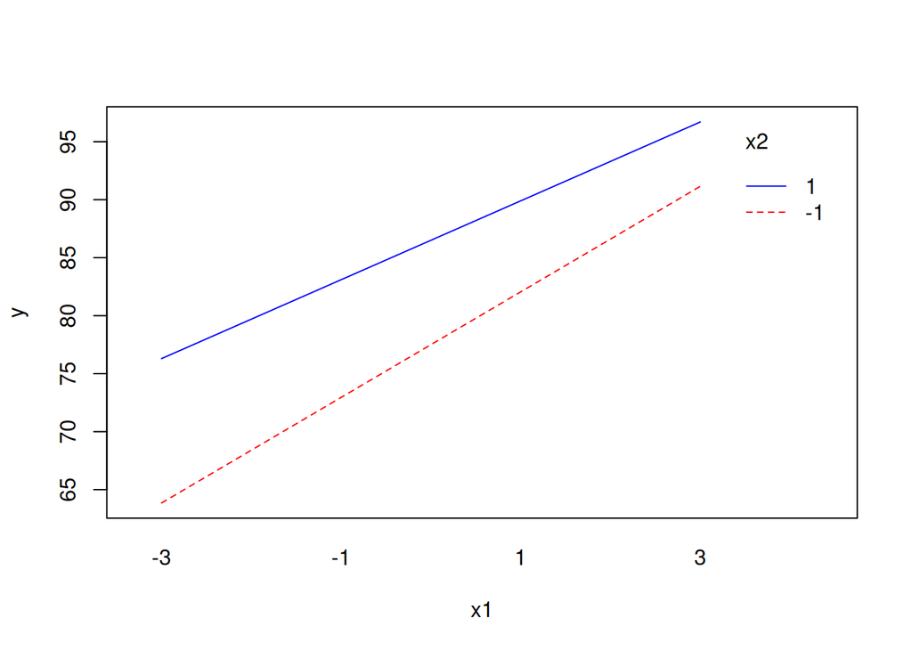

```r
# interaction model:
data2.xmod.fits = predict(data2.xmod)
interaction.plot(data2$x1,data2$x2,data2.xmod.fits,
            col=c("red","blue"),
            trace.label="x2",
            xlab="x1",
            ylab="y")
```

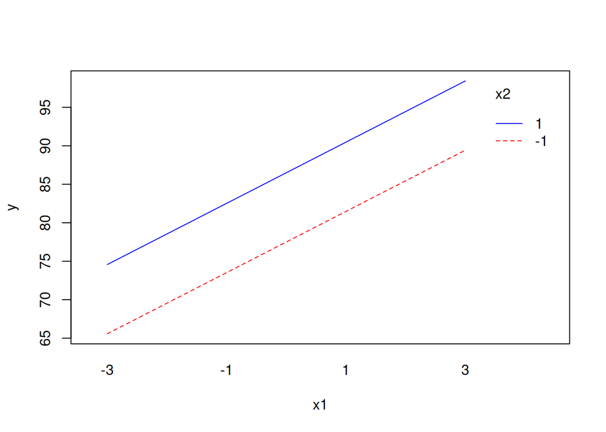

```r
# additive model
data2.amod = lm(satisfaction ~ x1+x2,data=data2)
data2.amod.fits = predict(data2.amod)
interaction.plot(data2$x1,data2$x2,data2.amod.fits,
            col=c("red","blue"),
            trace.label="x2",
            xlab="x1",
            ylab="y")
```

## P2: (f)

> Test for an interaction effect. (Compute the test statistic and $p$-value.)

```r
anova(data2.amod, data2.xmod)
```

```
## Analysis of Variance Table
##
## Model 1: satisfaction ~ x1 + x2
## Model 2: satisfaction ~ x1 * x2
##   Res.Df    RSS Df Sum of Sq      F  Pr(>F)
## 1     13 105.95
## 2     12  79.50  1     26.45 3.9925 0.06888 .
## ---
## Signif. codes:  0 '***' 0.001 '**' 0.01 '*' 0.05 '.' 0.1 ' ' 1
```

# Problem 3

> An engineer is interested in comparing three chemical processes (categorical input with groups $A$,$B$,$C$) for manufacturing a compound. It is suspected that the impurity (continuous input $x$) of the raw material will affect the yield (response variable $y$) of the product. The data is available on Blackboard as a csv file.

## P3: (e)

> Compute interval estimates for each of the effect parameters.

```r
library(matlib)
data3 = read.csv('exam2-3.csv')
data3$process = as.factor(data3$process)

contrasts(data3$process) = contr.treatment(3,base=3)
data3.amod = lm(yield ~ impurity+process,data=data3)

b.hat = coef(data3.amod)
dfe = nrow(model.matrix(data3.amod)) - ncol(model.matrix(data3.amod))
V = vcov(data3.amod)
a = c(0,0,1,-1)

b.hat.12 = a %*% b.hat
se.12 = sqrt(a %*% V %*% a)

b.hat.12.lower = b.hat.12 - qt(.975,dfe) * se.12
b.hat.12.upper = b.hat.12 + qt(.975,dfe) * se.12

confint(data3.amod)
```

```
##                 2.5 %    97.5 %
## (Intercept) 1.5446801 5.7006292
## impurity    0.1806097 0.9967766
## process1    4.3264225 7.3832047
## process2    2.2017852 5.0353307
```

```r
cat("beta2-beta1",c(b.hat.12.lower,b.hat.12.upper))
```

```
## beta2-beta1 0.5974664 3.875045
```

## P3: (f)

> Create a scatterplot of the data with the estimated regression lines.

```r
intercept.3 = b.hat[1]
intercept.1 = b.hat[1]+b.hat[3]
intercept.2 = b.hat[1]+b.hat[4]
slope = b.hat[2]

cat(slope, intercept.1, intercept.2, intercept.3)
```

```
## 0.5886932 9.477468 7.241213 3.622655
```

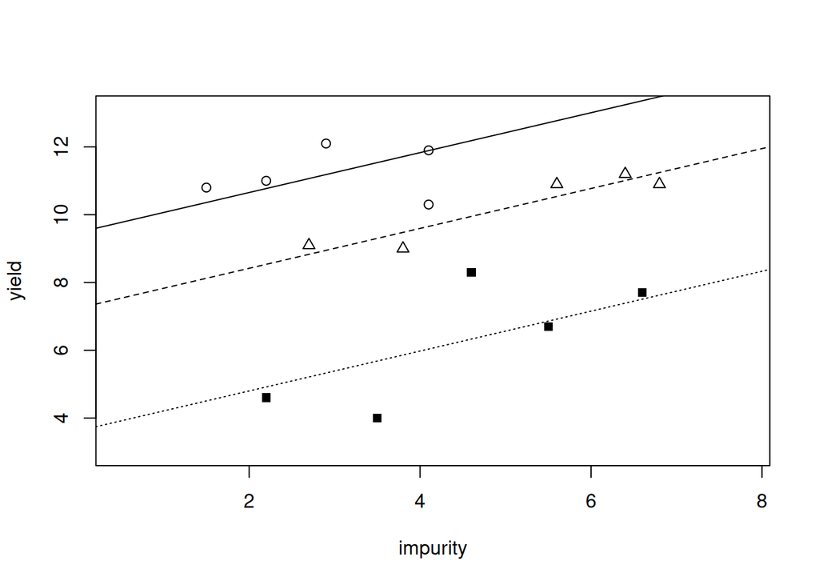

```r
attach(data3)

plot(impurity[process == "A"],yield[process == "A"],
     xlab='impurity',ylab='yield',pch=1,
     xlim=c(min(impurity)-1,max(impurity)+1),
     ylim=c(min(yield)-1,max(yield)+1))

points(impurity[process=="B"], yield[process=="B"], pch=2)
points(impurity[process=="C"], yield[process=="C"], pch=15)

abline(intercept.1,slope,lty=1)
abline(intercept.2,slope,lty=2)
abline(intercept.3,slope,lty=3)
```